# 街景字符识别（Bbox 路线冲 0.92+）

本 notebook 对应 `baseline.py` 的升级实现，目标是将验证集整串 Acc 提升到 0.92 以上。

核心思想：利用数据集中提供的字符 bbox，把任务拆成“单字符识别 + 字符排序拼接”，同时补充 YOLO 检测流程用于测试集推理。

## 1. 环境准备

- Python 3.10+
- PyTorch / torchvision
- pandas、numpy、matplotlib、Pillow、requests、tqdm
- 可选：`ultralytics`（用于 YOLO 检测分支）

```python
from pathlib import Path

from baseline import (
    Config,
    prepare_dataset,
    run_eda,
    visualize_char_crops,
    CharTrainer,
    eval_char_bbox,
    export_yolo_dataset,
    predict_detect,
    Trainer,
    predict,
    set_seed,
)

cfg = Config(
    data_list='./mchar_data_list_0515.csv',
    dataset_dir='./dataset',
    checkpoints='./checkpoints',
    result_csv='./result.csv',
    arch='resnet50',
    batch_size=64,
    epochs=30,
    char_arch='resnet18',
    char_batch_size=256,
    char_epochs=25,
    char_lr=5e-4,
    char_image_size=64,
    bbox_pad_ratio=0.15,
    seed=2026,
)
set_seed(cfg.seed)

best_char_model = ''
```

## 2. 下载与解压数据

```python
prepare_dataset(cfg.data_list, cfg.dataset_dir)
```

```
Skip existing file: dataset\mchar_train.zip
Skip existing file: dataset\mchar_train.json
Skip existing file: dataset\mchar_val.zip
Skip existing file: dataset\mchar_val.json
Skip existing file: dataset\mchar_test_a.zip
Skip existing file: dataset\mchar_sample_submit_A.csv
Skip extracted folder: dataset\mchar_train
Skip extracted folder: dataset\mchar_val
Skip extracted folder: dataset\mchar_test_a
train image counts: 30000
val image counts: 10000
test image counts: 40000
```

```
{'train_data': WindowsPath('dataset/mchar_train'),
 'val_data': WindowsPath('dataset/mchar_val'),
 'test_data': WindowsPath('dataset/mchar_test_a'),
 'train_label': WindowsPath('dataset/mchar_train.json'),
 'val_label': WindowsPath('dataset/mchar_val.json'),
 'submit_file': WindowsPath('dataset/mchar_sample_submit_A.csv')}
```

## 3. 数据统计（可选）

```
{'height': [219, 219], 'label': [1, 9], 'left': [246, 323], 'top': [77, 81], 'width': [81, 96]}
    file_name  file_code
0  000000.png          0
1  000001.png          0
2  000002.png          0
3  000003.png          0
4  000004.png          0
1个数字的图片数目: 4636
2个数字的图片数目: 16262
3个数字的图片数目: 7813
4个数字的图片数目: 1280
5个数字的图片数目: 8
6个数字的图片数目: 1
```

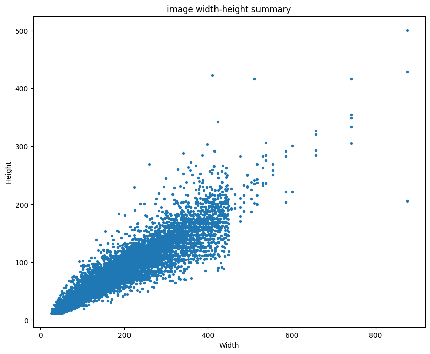

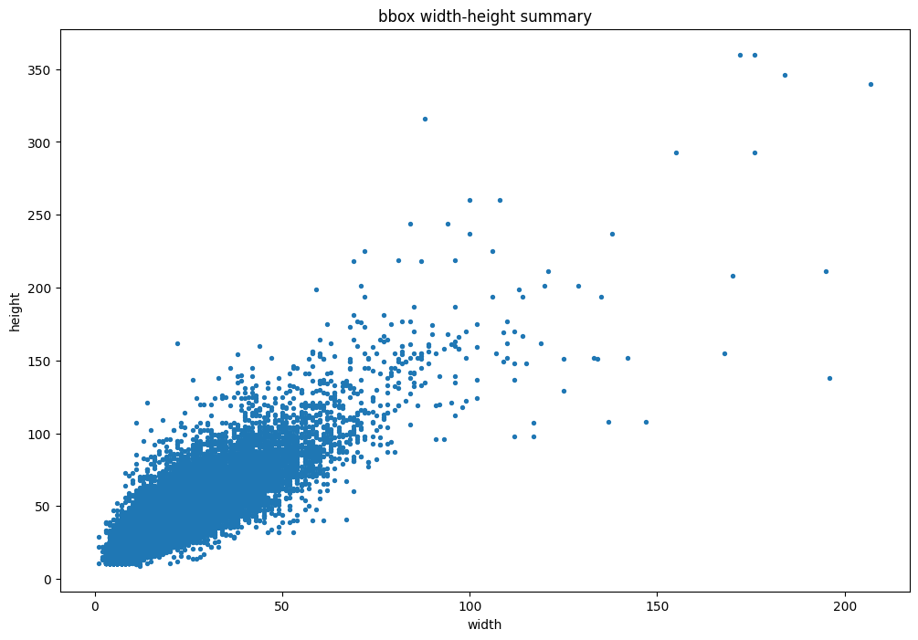

```python
run_eda(cfg.dataset_dir)
```

## 4. 可视化字符裁剪结果

用于检查 bbox 裁剪是否正确、padding 是否合适。

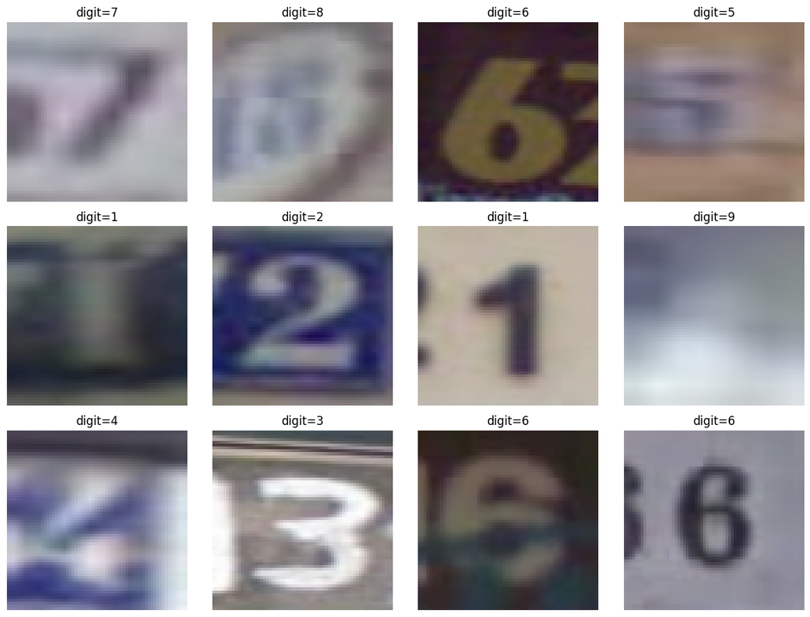

```python
visualize_char_crops(cfg.dataset_dir, mode='train', sample_count=12, pad_ratio=cfg.bbox_pad_ratio)
```

## 5. 训练字符分类模型（关键）

```python
char_trainer = CharTrainer(cfg)
best_char_model = char_trainer.train()
print('best_char_model:', best_char_model)
print('best_char_acc:', char_trainer.best_char_acc)
```

```
Downloading: "https://download.pytorch.org/models/resnet18-f37072fd.pth" to C:\Users\mimiqi/.cache\torch\hub\checkpoints\resnet18-f37072fd.pth
```

```
[Char] epoch=1/25 train_loss=0.4092 train_acc=0.8715 val_char_acc=0.9294
Best char checkpoint saved: checkpoints\char-resnet18-epoch-1-acc-92.94.pth
```

```
[Char] epoch=2/25 train_loss=0.2103 train_acc=0.9386 val_char_acc=0.9444
Best char checkpoint saved: checkpoints\char-resnet18-epoch-2-acc-94.44.pth
```

```
[Char] epoch=3/25 train_loss=0.1702 train_acc=0.9508 val_char_acc=0.9339
```

```
[Char] epoch=4/25 train_loss=0.1452 train_acc=0.9587 val_char_acc=0.9469
Best char checkpoint saved: checkpoints\char-resnet18-epoch-4-acc-94.69.pth
```

```
[Char] epoch=5/25 train_loss=0.1235 train_acc=0.9646 val_char_acc=0.9447
```

```
[Char] epoch=6/25 train_loss=0.1072 train_acc=0.9687 val_char_acc=0.9500
Best char checkpoint saved: checkpoints\char-resnet18-epoch-6-acc-95.00.pth
```

```
[Char] epoch=7/25 train_loss=0.0906 train_acc=0.9732 val_char_acc=0.9532
Best char checkpoint saved: checkpoints\char-resnet18-epoch-7-acc-95.32.pth
```

```
[Char] epoch=8/25 train_loss=0.0789 train_acc=0.9768 val_char_acc=0.9516
```

```
[Char] epoch=9/25 train_loss=0.0647 train_acc=0.9806 val_char_acc=0.9535
Best char checkpoint saved: checkpoints\char-resnet18-epoch-9-acc-95.35.pth
```

```
[Char] epoch=10/25 train_loss=0.0541 train_acc=0.9836 val_char_acc=0.9520
```

```
[Char] epoch=11/25 train_loss=0.0432 train_acc=0.9870 val_char_acc=0.9560
Best char checkpoint saved: checkpoints\char-resnet18-epoch-11-acc-95.60.pth
```

```
[Char] epoch=12/25 train_loss=0.0366 train_acc=0.9889 val_char_acc=0.9560
```

```
[Char] epoch=13/25 train_loss=0.0304 train_acc=0.9906 val_char_acc=0.9504
```

```
[Char] epoch=14/25 train_loss=0.0248 train_acc=0.9920 val_char_acc=0.9559
```

```
[Char] epoch=15/25 train_loss=0.0184 train_acc=0.9944 val_char_acc=0.9575
Best char checkpoint saved: checkpoints\char-resnet18-epoch-15-acc-95.75.pth
```

```
[Char] epoch=16/25 train_loss=0.0118 train_acc=0.9963 val_char_acc=0.9578
Best char checkpoint saved: checkpoints\char-resnet18-epoch-16-acc-95.78.pth
```

```
[Char] epoch=17/25 train_loss=0.0130 train_acc=0.9956 val_char_acc=0.9578
```

```
[Char] epoch=18/25 train_loss=0.0086 train_acc=0.9972 val_char_acc=0.9561
```

```
[Char] epoch=19/25 train_loss=0.0068 train_acc=0.9979 val_char_acc=0.9588
Best char checkpoint saved: checkpoints\char-resnet18-epoch-19-acc-95.88.pth
```

```
[Char] epoch=20/25 train_loss=0.0055 train_acc=0.9982 val_char_acc=0.9604
Best char checkpoint saved: checkpoints\char-resnet18-epoch-20-acc-96.04.pth
```

```
[Char] epoch=21/25 train_loss=0.0049 train_acc=0.9985 val_char_acc=0.9591
```

```
[Char] epoch=22/25 train_loss=0.0040 train_acc=0.9988 val_char_acc=0.9610
Best char checkpoint saved: checkpoints\char-resnet18-epoch-22-acc-96.10.pth
```

```
[Char] epoch=23/25 train_loss=0.0038 train_acc=0.9988 val_char_acc=0.9605
```

```
[Char] epoch=24/25 train_loss=0.0032 train_acc=0.9990 val_char_acc=0.9619
Best char checkpoint saved: checkpoints\char-resnet18-epoch-24-acc-96.19.pth
```

```
[Char] epoch=25/25 train_loss=0.0032 train_acc=0.9990 val_char_acc=0.9613
best_char_model: checkpoints\char-resnet18-epoch-24-acc-96.19.pth
best_char_acc: 0.9618961443723923
```

## 6. 验证集整串 Acc（使用真实 bbox）

这个指标直接对应课程评分中的验证集 Acc。目标：`> 0.92`。

```python
if not best_char_model:
    raise ValueError("best_char_model 为空，请先执行第 5 节训练单元。")

val_seq_acc = eval_char_bbox(best_char_model, cfg, mode='val')
print('val full-sequence acc:', val_seq_acc)
```

```
[Char+BBox] val full-sequence Acc: 0.9341
val full-sequence acc: 0.9341
```

## 7. 导出 YOLO 检测数据

训练集/验证集会被转换为 YOLO 标注格式，输出 `digit.yaml`。

```python
yaml_path = export_yolo_dataset(cfg)
print('yolo yaml:', yaml_path)
```

```
YOLO dataset exported to: dataset\yolo_digit
YOLO yaml file: dataset\yolo_digit\digit.yaml
yolo yaml: dataset\yolo_digit\digit.yaml
```

## 8. 训练 YOLO（在终端执行）

示例命令：

```
pip install ultralytics
yolo detect train model=yolov8n.pt data=dataset/yolo_digit/digit.yaml epochs=100 imgsz=640
```

训练完成后得到 detector 权重，例如 `runs/detect/train/weights/best.pt`。

## 9. 测试集检测 + 识别推理

- 只用 detector 类别输出：不传 `char_model_path`
- 检测框再用字符分类器精修：传入 `char_model_path=best_char_model`（推荐）

```python
detector_path = Path('runs/detect/train/weights/best.pt')  # 修改为你的实际路径
if not detector_path.exists():
    raise FileNotFoundError(f"未找到检测器权重: {detector_path}")

char_model_path = best_char_model if best_char_model else ''
if not char_model_path:
    print("未提供字符分类器，将只使用 detector 类别输出。")

predict_detect(
    detector_model_path=str(detector_path),
    csv_path=cfg.result_csv,
    cfg=cfg,
    char_model_path=char_model_path,
)
print('submit file:', cfg.result_csv)
```

[output not shown]

## 10. 对照实验：整图 baseline（可选）

可用于报告对比，说明 bbox 方案带来的收益。

```python
trainer = Trainer(cfg)
best_whole_model = trainer.train()
print('whole-image baseline best model:', best_whole_model)
print('whole-image baseline best val acc:', trainer.best_acc)
```

[output not shown]

## 11. 报告填写建议

- 验证集整串 Acc：填写第 6 节结果（目标 > 0.92）
- 实现方案：写明 bbox 裁剪、字符分类、排序拼接、检测分支
- 涨点分析：对比整图 baseline 与 bbox 路线，说明哪些增强和超参数最有效
- 复现命令：优先贴 `python baseline.py train-char`、`python baseline.py eval-char-bbox`、`python baseline.py export-yolo`、`python baseline.py predict-detect ...`